# R Puerto Rico Hurricane Reassessment

On September 20, 2017, Hurricane Maria laded on Puerto Rico, resulting considerable damage. However, the initial accessment reported only 64 deaths from the hurricane, as the most of fatalities were caused by infrastructure damage, such as lack of clean waters, power, healthcare, etc. To calibrate for indirect fatalities, Statisticians performed numerous data analysis. In this projects, it will read datas from pdf and follows statistical and text mining procedures.

```r
library(tidyverse)
library(pdftools)
library(dslabs)
options(digits = 3)
options(width = 60)
fn <- system.file("extdata", "RD-Mortality-Report_2015-18-180531.pdf", package="dslabs")
#system("cmd.exe", input = paste("start", fn))
txt <- pdf_text(fn)
txt[1]
```

```
## [1] "6/4/2018                                Departamento de Salud - Registro Demográfico - División de Calidad y Estadísticas Vitales\n\n JAN    2015    2016    2017    2018\n    1     107      89     107      95\n    2     101      88     108     107                                             …
```

The study was published in PDF format with inline table and figures. pdf_text() from pdf tools converts pdf into string array, where each index represents pdf page number. For the sake of demonstration, page #9 was chosen to be analyzed.

```r
sample9 <- txt[9]
library(stringr)
library(dplyr)
x <- sample9 %>% str_split("\n")
print(x)
```

```
## [[1]]
##  [1] "6/4/2018                                         Departamento de Salud - Registro Demográfico - División de Calidad y Estadísticas Vitales"
##  [2] ""
##  [3] "SEP     2015    2016     2017    2018"
##  [4] "    1      75      75       94          0"
##  [5] "    2      77      67       69          0                                                                       Defunciones Ocurridas en Septiembre por Día y Año"
##  [6] "    3      67      78       80          0"
##  [7] "                                              140"
##  [8] "    4      71      99       84          0"
##  [9] "    5      62      89       74          0"
## [10] "                                              120"
## [11] "    6      77      74       83          0"
## [12] "    7      85      67       87          0"
## [13] "    8      84      77       94          0     100"
## [14] "    9      79      90       72          0"
```

[output cut: 27 more lines]

```r
print(length(x))
```

```
## [1] 1
```

```r
s <- x[[1]] %>% str_trim()

class(s)
```

```
## [1] "character"
```

```r
length(s)
```

```
## [1] 41
```

pdf_text made string array and each entries are character vector. We extracted character vector s. Upon inspection, it is a string containing table published by “Departamento de Salud,” on hurrican casualties.

```r
header_index <- s %>% str_which("2015")
header_index
```

```
## [1]  3 25
```

```r
s[header_index]
```

```
## [1] "SEP     2015    2016     2017    2018"
## [2] "20      69      79      106          0    Fuente: Registro Demográfico - División de Calidad y Estadísticas Vitales              2015          2016         2017        2018"
```

```r
header_index <- header_index[1]
```

from pattern matching, we found 3rd line is the one with the header containing years.

```r
temp <- s[header_index] %>% str_split("\\s+", simplify = TRUE)
temp
```

```
##      [,1]  [,2]   [,3]   [,4]   [,5]
## [1,] "SEP" "2015" "2016" "2017" "2018"
```

```r
month <- temp[1]
years <- temp[2:5]
```

By finding 1 or more characters, months and years are separated.

```r
tail_index <- s %>% str_which("Total")
tail_index
```

```
## [1] 36
```

```r
n <- s %>% str_count("\\d+")
sum(n==1)
```

```
## [1] 2
```

We separated header, single-valued rows due to a graph in PDF, and mixed tables.

```r
which(n==1)
```

```
## [1]  7 10
```

```r
filtered <- s[(header_index+1):(tail_index-1)]
filtered[-c(which(n==1))]
```

```
##  [1] "1      75      75       94          0"
##  [2] "2      77      67       69          0                                                                       Defunciones Ocurridas en Septiembre por Día y Año"
##  [3] "3      67      78       80          0"
##  [4] "140"
##  [5] "4      71      99       84          0"
##  [6] "5      62      89       74          0"
##  [7] "6      77      74       83          0"
##  [8] "7      85      67       87          0"
##  [9] "9      79      90       72          0"
## [10] "10      66      73       98          0      80"
## [11] "11      92      78       92          0"
## [12] "12      79      66       80          0      60"
## [13] "13      81      88      100          0"
## [14] "14      70      81       79          0      40"
## [15] "15      87      91       84          0"
## [16] "16      70      71       80          0      20"
## [17] "17      70      68       88          0"
## [18] "18      76      79       78          0       0"
## [19] "19      81      82       75          0              1      2      3       4      5      6       7      8      9       10   11   12   13   14      15   16     17   18    19    20   21   22   23   24   25   26   27   28   29   30"
## [20] "20      69      79      106          0    Fuente: Registro Demográfico - División de Calidad y Estadísticas Vitales              2015          2016         2017        2018"
## [21] "21      70      67      124          0"
## [22] "22      68      97      110          0"
## [23] "23      70      71      109          0"
## [24] "24      78      79      122          0"
## [25] "25      60      75      137          0"
## [26] "26      76      82      132          0"
## [27] "27      78      82      122          0"
## [28] "28      84      81      112          0"
## [29] "29      83      70      131          0"
## [30] "30      73      91      132          0"
```

Since we still have non-numeric values, it can be removed using regex.

```r
new_filtered <- filtered %>% str_remove_all("[^\\d\\s]")
new_filtered
```

```
##  [1] "1      75      75       94          0"
##  [2] "2      77      67       69          0                                                                              "
##  [3] "3      67      78       80          0"
##  [4] "140"
##  [5] "4      71      99       84          0"
##  [6] "5      62      89       74          0"
##  [7] "120"
##  [8] "6      77      74       83          0"
##  [9] "7      85      67       87          0"
## [10] "8      84      77       94          0     100"
## [11] "9      79      90       72          0"
## [12] "10      66      73       98          0      80"
## [13] "11      92      78       92          0"
## [14] "12      79      66       80          0      60"
## [15] "13      81      88      100          0"
```

[output cut: 17 more lines]

```r
s <- str_split_fixed(new_filtered, "\\s+", n = 6)[,1:5]
colnames(s) = c("day", years)
s[which(s=="")] = NA
finalResult <- s %>% na.omit()
finalResult
```

```
##       day  2015 2016 2017  2018
##  [1,] "1"  "75" "75" "94"  "0"
##  [2,] "2"  "77" "67" "69"  "0"
##  [3,] "3"  "67" "78" "80"  "0"
##  [4,] "4"  "71" "99" "84"  "0"
##  [5,] "5"  "62" "89" "74"  "0"
##  [6,] "6"  "77" "74" "83"  "0"
##  [7,] "7"  "85" "67" "87"  "0"
##  [8,] "8"  "84" "77" "94"  "0"
##  [9,] "9"  "79" "90" "72"  "0"
## [10,] "10" "66" "73" "98"  "0"
## [11,] "11" "92" "78" "92"  "0"
## [12,] "12" "79" "66" "80"  "0"
## [13,] "13" "81" "88" "100" "0"
## [14,] "14" "70" "81" "79"  "0"
```

[output cut: 20 more lines]

Found basic statistics of data, with data tidying,

```r
option1 <- as.character("2015":"2018")
report <- subset(finalResult, TRUE, option1)
class(report) <- "numeric"
colMeans(report)
```

```
## 2015 2016 2017 2018
## 75.3 78.9 97.6  0.0
```

Hurricane Maria hit Puerto Rico on September 20, 2017. With this information, we would like to see change in the mean number of deaths. Statistics, it is called paired-t testing, after data wrangling one may pursue further statistical analysis with tidy data.

```r
print(report[1:19,"2017"] %>% mean())
```

```
## [1] 83.7
```

```r
print(report[20:30,"2017"] %>% mean())
```

```
## [1] 122
```

It can be observed that $\mu_{prev} = 83.7$ and $\mu_{now} = 122$ One can finalize tidy process by explicitly converting into tidyr format.

```r
finalResult <- finalResult[, colnames(finalResult)[1:4]]
class(finalResult) <- "numeric"
finalResult
```

```
##       day 2015 2016 2017
##  [1,]   1   75   75   94
##  [2,]   2   77   67   69
##  [3,]   3   67   78   80
##  [4,]   4   71   99   84
##  [5,]   5   62   89   74
##  [6,]   6   77   74   83
##  [7,]   7   85   67   87
##  [8,]   8   84   77   94
##  [9,]   9   79   90   72
## [10,]  10   66   73   98
## [11,]  11   92   78   92
## [12,]  12   79   66   80
## [13,]  13   81   88  100
## [14,]  14   70   81   79
```

[output cut: 16 more lines]

```r
finalResult <- data.frame(finalResult)
colnames(finalResult) = c("day", "2015", "2016", "2017")
finalResult
```

| day | 2015 | 2016 | 2017 |
| --- | --- | --- | --- |
| 1 | 75 | 75 | 94 |
| 2 | 77 | 67 | 69 |
| 3 | 67 | 78 | 80 |
| 4 | 71 | 99 | 84 |
| 5 | 62 | 89 | 74 |
| 6 | 77 | 74 | 83 |
| 7 | 85 | 67 | 87 |
| 8 | 84 | 77 | 94 |
| 9 | 79 | 90 | 72 |
| 10 | 66 | 73 | 98 |

[output cut: 20 more lines]

```r
tab <- finalResult %>% gather(year, deaths, -day) %>%
  mutate(deaths = as.numeric(deaths))
tab
```

| day | year | deaths |
| --- | --- | --- |
| 1 | 2015 | 75 |
| 2 | 2015 | 77 |
| 3 | 2015 | 67 |
| 4 | 2015 | 71 |
| 5 | 2015 | 62 |
| 6 | 2015 | 77 |
| 7 | 2015 | 85 |
| 8 | 2015 | 84 |
| 9 | 2015 | 79 |
| 10 | 2015 | 66 |

[output cut: 80 more lines]

One may proceed with further analysis with tidied data.

[output not shown]

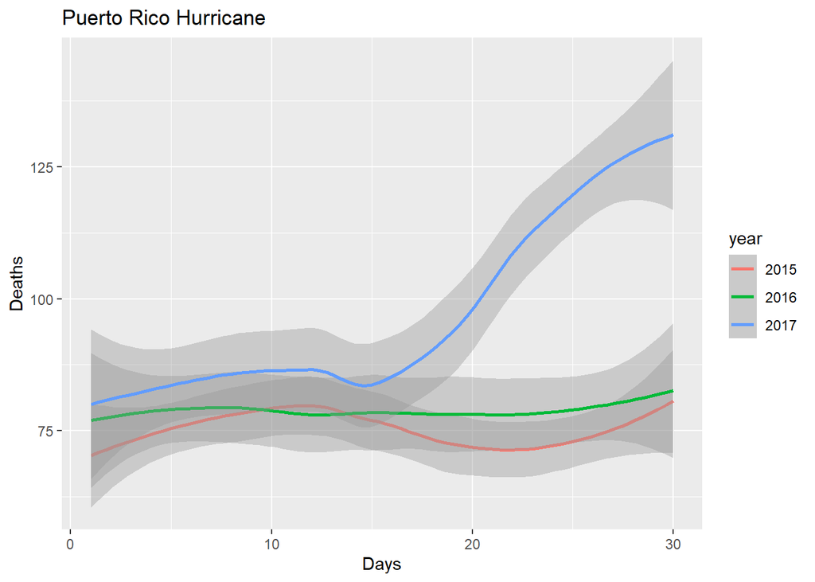

```r
library(ggplot2)
tab %>% ggplot() +
  geom_smooth(aes(x = day, y=deaths, color = year)) +
  ggtitle("Puerto Rico Hurricane") +
  xlab("Days") +
  ylab("Deaths")
```